# Normal (Gaussian) Distribution: R Code

October 20, 2021 @ 12:27 PM

## Before We Begin…

These slides are not meant to be standalone information. You should take notes to flesh out the contents. I recommend that you create an R Markdown document where you can combine information and code from the slides and your own additional notes and explorations to make connections.

**Related Materials**

- Ch 2 of *Mathematical Statistics with Resampling and R, 2<sup>nd</sup> Ed.*
- [Appendix A](https://moderndive.com/A-appendixA.html) of *Modern Dive*
- DataCamp [Foundations of Probability in R](https://www.datacamp.com/courses/foundations-of-probability-in-r)
- [Normal (Gaussian) Distribution: The Math](https://stat-jet-asu.github.io/StatisticalDataAnalysis1/Slides/NormalDistributionTheory.html) class slides
- [Normal (Gaussian) Distribution: Assessing](https://stat-jet-asu.github.io/StatisticalDataAnalysis1/Slides/NormalAssessment.html) (slides)

## Index

- Slides 02-03 — Materials & Index
- Slides 04-06 — Model Overview
  - Slide 05 — The Normal Model
  - Slide 06 — The Empirical Rule
- Slides 07-10 — Working With the PMF
- Slides 11-19 — Working With the CDF
  - Slides 12-14 — CDF and Visualization
  - Slides 15-17 — Area Under the Curve
  - Slides 18-19 — The Inverse CDF
- Slides 20-25 — Sampling and Simulation

## Model Overview

## The Normal Model

\[X \sim N(\mu,\sigma^2)\]

\(x\) = {-\(\infty\) to +\(\infty\)}

\(\mu\) = the mean of the distribution

\(\sigma^2\) = the variance of the distribution

\[f(x)=\frac{1}{\sqrt{2\pi}\sigma}e^{-(x-\mu)^2/(2\sigma^2)}\]

\[F(x) = \text{no closed-form solution}\]

\[E[X] = \mu \text{ and }Var[X] = \sigma^2\]

## The Empirical Rule

The normal distribution is unimodal and perfectly symmetric.

[figure not shown]

- approximately 68% of the curve’s area is between \(\mu \pm 1\sigma\)
- approximately 95% of the curve’s area is between \(\mu \pm 2\sigma\)
- approximately 99.7% of the curve’s area is between \(\mu \pm 3\sigma\)

The tails extend to \(\pm \infty\) ; any value of \(x\) is *theoretically possible*.

## Working With the PMF

## Calculating the pmf or f(x)

Recall the normal model’s probability mass function (pmf).

\[f(x)=\frac{1}{\sqrt{2\pi}\sigma}e^{-(x-\mu)^2/(2\sigma^2)}\]

R has a function to solve the pmf for any normal model. Inputs may be single values or vectors. *We only use this for plotting the normal distribution, not for calculating probabilities.*

\(f(x)\) = `dnorm(x, mean, sd)`

Note that the `R` function uses standard deviation (\(\sigma\)) rather than the variance (\(\sigma^2\)) as an input (argument) to the function.

## Plotting the Standard Normal Z

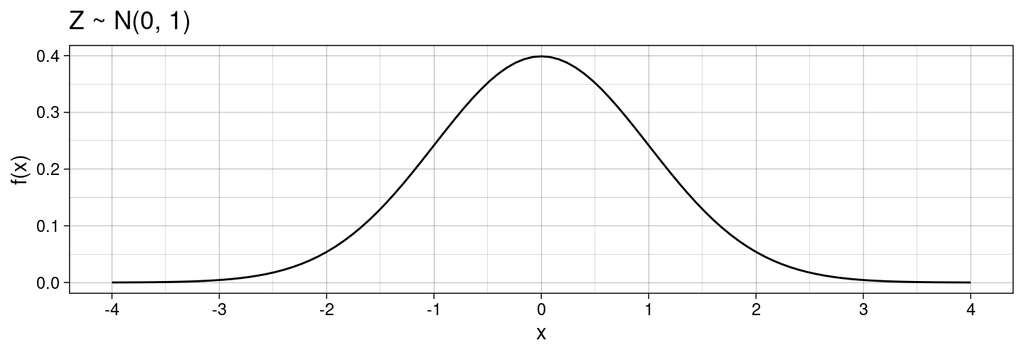

```r
ggplot() +
  stat_function(fun = dnorm,
                args = list(0, 1)) +
  scale_x_continuous(limits = c(-4, 4),
                     breaks = seq(from = -4, to = 4, by = 1)) +
  labs(title = "Z ~ N(0, 1)", x = "x", y = "f(x)") +
  theme_linedraw()
```

## General Plotting Code

```r
# set the parameters of the normal model
mu    <- 0
sigma <- 1

# adapt the labels for the given problem
ggplot() +
  stat_function(fun = dnorm,
                args = list(mu, sigma)) +
  scale_x_continuous(limits = c(mu - (4 * sigma),
                                mu + (4 * sigma)),
                     breaks = seq(from = mu - (4 * sigma),
                                  to   = mu + (4 * sigma),
                                  by   = sigma)) +
  labs(title = "informative title here",
       x = "description and units of x",
       y = "f(x)") +
  theme_linedraw()
```

## Working With the CDF

## Cumulative Distribution Function (CDF)

Recall also the normal model’s CDF.

\[F(x)=P(X \leq x) = \int\limits_{-\infty}^{x} \frac{1}{\sqrt{2\pi}\sigma}e^{-(x-\mu)^2/(2\sigma^2)}dx\]

\(P(X \leq x)\) = `pnorm(q, mean, sd, lower.tail = TRUE)`

\(P(X > x)\) = `pnorm(q, mean, sd, lower.tail = FALSE)`

For any continuous distribution \(P(X = x) = 0\) (area under a single point is zero). Therefore, \(P(X \leq x)\) and \(P(X < x)\) are mathematically equivalent. However, we might use a *continuity correction* when approximating discretely measured data.

## Plotting the Standard Normal Z

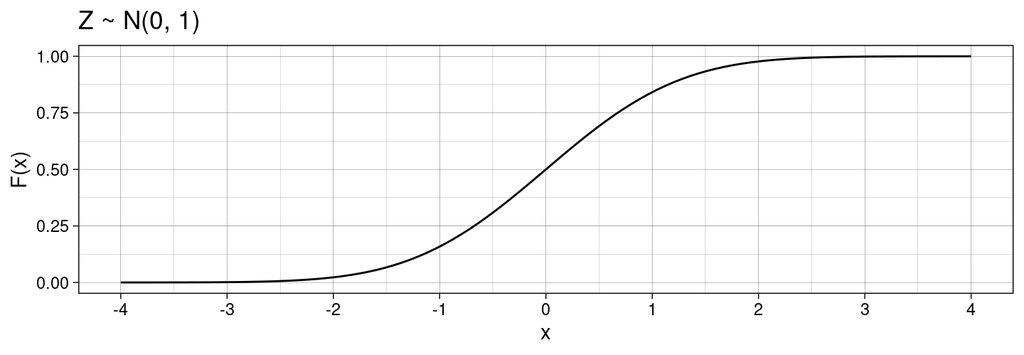

```r
ggplot() +
  stat_function(fun = pnorm,
                args = list(0, 1)) +
  scale_x_continuous(limits = c(-4, 4),
                     breaks = seq(from = -4, to = 4, by = 1)) +
  labs(title = "Z ~ N(0, 1)", x = "x", y = "F(x)") +
  theme_linedraw()
```

## General Plotting Code

```r
# set the parameters of the normal model
mu    <- 0
sigma <- 1

# adapt the labels for the given problem
ggplot() +
  stat_function(fun = pnorm,
                args = list(mu, sigma)) +
  scale_x_continuous(limits = c(mu - (4 * sigma),
                                mu + (4 * sigma)),
                     breaks = seq(from = mu - (4 * sigma),
                                  to   = mu + (4 * sigma),
                                  by   = sigma)) +
  labs(title = "informative title here",
       x = "description and units of x",
       y = "F(x)") +
  theme_linedraw()
```

## Solving for Area Under the Curve #1

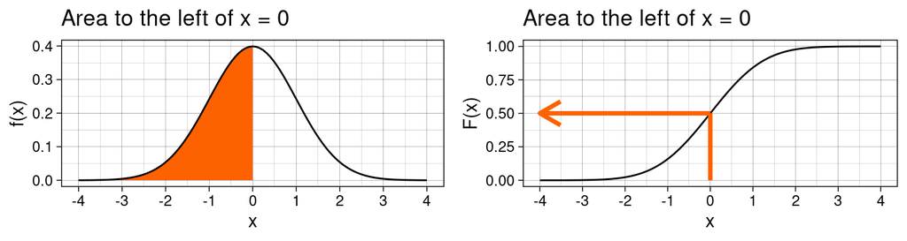

```r
pnorm(q = 0, mean = 0, sd = 1) #lower.tail = TRUE is the default
```

```
[1] 0.5
```

```r
pnorm(q = 0, mean = 0, sd = 1, lower.tail = FALSE) #area above 0
```

```
[1] 0.5
```

## Solving for Area Under the Curve #2

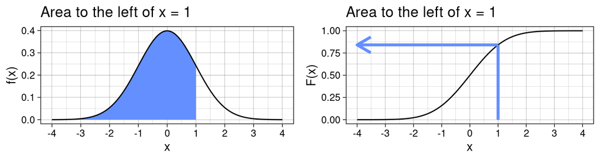

```r
pnorm(q = 1, mean = 0, sd = 1) #lower.tail = TRUE is the default
```

```
[1] 0.8413447
```

```r
pnorm(q = 1, mean = 0, sd = 1, lower.tail = FALSE) # area above 1
```

```
[1] 0.1586553
```

## Solving for Area Between Two Values

\[F(x)=P(X \leq x) = \int\limits_{0}^{1} \frac{1}{\sqrt{2\pi}\sigma}e^{-(x-\mu)^2/(2\sigma^2)}dx\]

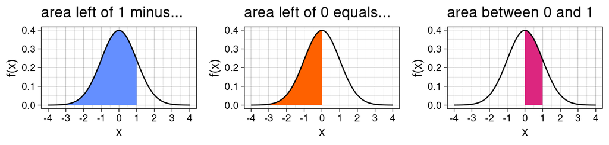

```r
pnorm(q = 1, mean = 0, sd = 1) - pnorm(q = 0, mean = 0, sd = 1)
```

```
[1] 0.3413447
```

## The Inverse CDF

In the discussions above, we found the area to the left of a given point (or *quantile*) on the x-axis. Sometimes we need to solve the reverse kind of problem: given an area or probability, what is the corresponding quantile or quantiles?

\(F^{-1}(x)\) = `qnorm(p, mean, sd, lower.tail = TRUE)`

If the area is to the right of the unknown value x (the upper tail) rather than to the left (the lower tail), then specify upper tail.

\(F^{-1}(x)\) = `qnorm(p, mean, sd, lower.tail = FALSE)`

If we know \(\mu\), \(\sigma\), and either the value(s) of x or the area(s)…

`qnorm(p, mean, sd) = q` \(\Longleftrightarrow\) `pnorm(q, mean, sd) = p`

## Solving for the Quantile

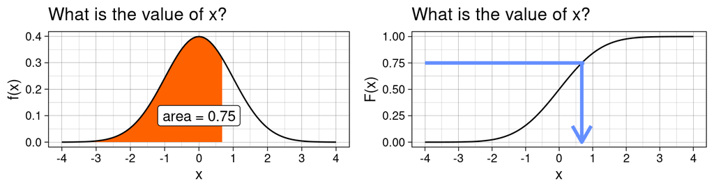

```r
(x_val <- qnorm(p = .75, mean = 0, sd = 1))
```

```
[1] 0.6744898
```

```r
pnorm(q = x_val, mean = 0, sd = 1)   # check the x, we get the area
```

```
[1] 0.75
```

## Sampling and Simulating

## Sampling from a Normal Distribution

In addition to calculating probabilities, we can simulate random normal values in `R` using `rnorm(n, mean, sd)`.

*n* = the number of random values (sample size)

*mean* = the mean of the distribution

*sd* = the standard deviation of the distribution

As with the other *norm* functions, the default parameter settings in `rnorm()` are `mean = 0` and `sd = 1`.

If we want a sample from the standard normal distribution, we only need to enter a value for sample size, `rnorm(n)`.

```r
rnorm(5)
```

```
[1] -0.7760821  0.2239929 -0.2426674 -0.4977446  2.4173138
```

```r
rnorm(10)
```

```
 [1]  1.5513730 -1.3554746  2.0049384  0.1165194 -0.7573172 -0.2404855
 [7] -1.6286618 -1.3093598  0.1391205 -0.2733148
```

```r
rnorm(25)
```

```
 [1]  0.12684740  0.03406337  0.18595381  0.25702041  0.29170809  0.02095911
 [7] -1.53093627  0.27864483  0.54320676 -0.40985562  0.51402852 -1.57896094
[13]  0.62967503  0.75816645 -0.62499922 -1.30272088  0.07101620  1.27589919
[19]  0.73653847  0.52708335 -0.46119119 -0.38694803  0.49238839  1.08703584
[25] -0.28399060
```

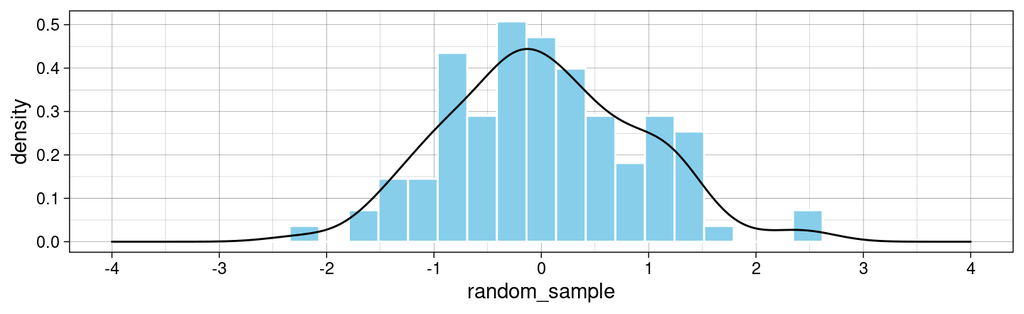

```r
random_sample <- rnorm(100)
ggplot(NULL, aes(x = random_sample)) +
  geom_histogram(aes(y = ..density..),
                 bins = 30,
                 fill = "skyblue",
                 color = "white") +
  geom_density() +
  scale_x_continuous(limits = c(-4, 4),
                     breaks = seq(from = -4, to = 4, by = 1)) +
  theme_linedraw()
```

## Sample of Size 1000

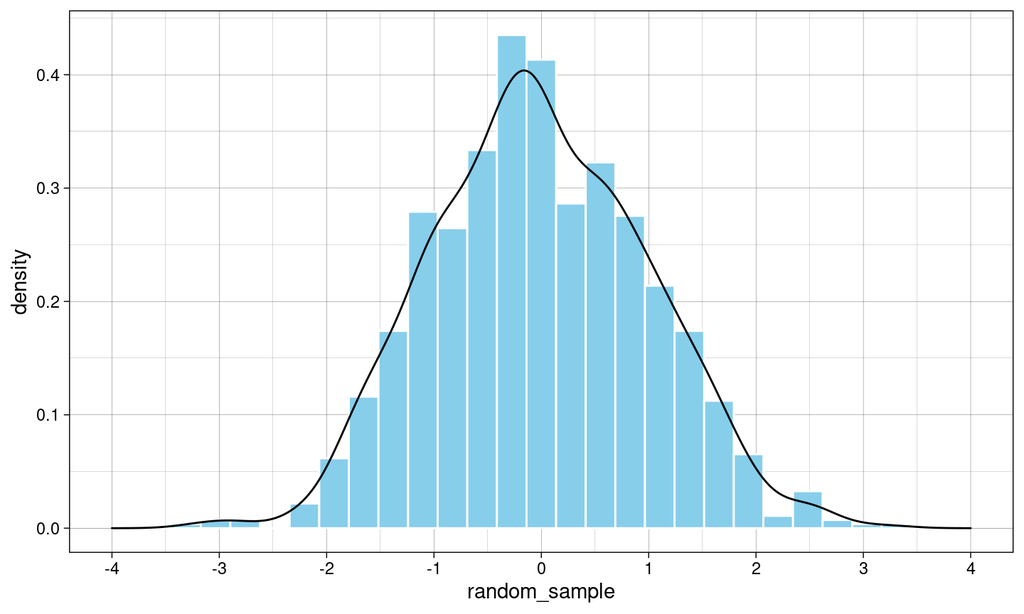

## Sample of Size 1,000,000

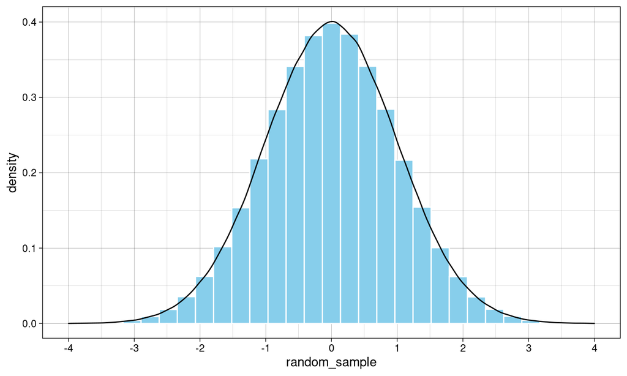